# Feature Engineering on the Cleaned Final Data Set

```python
import numpy as np
import pandas as pd
import matplotlib.pyplot as plt
%matplotlib inline
```

#### Reading the cleaned final dataset

```python
tmc_finaldata = pd.read_csv("tmc_final_data.csv")
```

```python
tmc_finaldata.head()
```

|  | DAY_DT | LOC_IDNT | DBSKU | FULL_PRICE_IND | TOTAL_SALES | TOTAL_UNITS | TOTAL_SALES_PRFT | TOTAL_COST | UNIT_SALES_PRICE | CITY | STATE | STORE_TYPE | POSTAL_CD | STORE_SIZE | DEPARTMENT | CLASS | SUBCLASS | SUBCLASS_NAME | DSUBCLASS |
| --- | --- | --- | --- | --- | --- | --- | --- | --- | --- | --- | --- | --- | --- | --- | --- | --- | --- | --- | --- |
| 0 | 2015-09-26 | 1218 | 466896.0 | 0 | 16.80 | 1.0 | 1.3000 | 15.5000 | 16.80 | COLUMBIA | SC | Lifestyle Center | 29229.0 | 3050.0 | 10.0 | 3.0 | 31.0 | Sub Class 2 | 1031.0 |
| 1 | 2015-08-02 | 1218 | 412445.0 | 0 | 29.99 | 1.0 | 12.9900 | 17.0000 | 29.99 | COLUMBIA | SC | Lifestyle Center | 29229.0 | 3050.0 | 10.0 | 2.0 | 21.0 | Sub Class 2 | 1021.0 |
| 2 | 2015-10-21 | 1218 | 491738.0 | 1 | 44.00 | 1.0 | 28.2500 | 15.7500 | 44.00 | COLUMBIA | SC | Lifestyle Center | 29229.0 | 3050.0 | 10.0 | 5.0 | 50.0 | Sub Class 3 | 1050.0 |
| 3 | 2015-08-02 | 1218 | 414979.0 | 0 | 24.00 | 1.0 | 6.9936 | 17.0064 | 24.00 | COLUMBIA | SC | Lifestyle Center | 29229.0 | 3050.0 | 10.0 | 3.0 | 32.0 | Sub Class 1 | 1032.0 |
| 4 | 2015-07-26 | 1218 | 458372.0 | 1 | 48.00 | 1.0 | 30.0000 | 18.0000 | 48.00 | COLUMBIA | SC | Lifestyle Center | 29229.0 | 3050.0 | 10.0 | 3.0 | 32.0 | Sub Class 1 | 1032.0 |

### Dropping the insignificant Variables and reasons

- 'DEPARTMENT', 'SUBCLASS' are replaced with its equivalent "DSUBCLASS" and 'CLASS','SUBCLASS_NAME' are insignificant
- 'LOC_IDNT', 'POSTAL_CD' is represented with corresponding CITY, STATE, STORE_TYPE and STORE_SIZE, hence Dropping it
- 'TOTAL_SALES_PRFT', 'TOTAL_COST', 'TOTAL_SALES' are replaced with a Derived Column 'UNIT_SALES_PRICE'
- 'CITY' - at this stage of initial modelling we are analysing Statewise rather than Citywise

```python
tmc_finaldata.drop(['DEPARTMENT','CLASS','SUBCLASS_NAME','SUBCLASS','LOC_IDNT','TOTAL_SALES_PRFT','TOTAL_COST',
                    'TOTAL_SALES','POSTAL_CD','CITY'],axis=1,inplace=True)
```

```python
tmc_finaldata.dtypes
```

```
DAY_DT               object
DBSKU               float64
FULL_PRICE_IND        int64
TOTAL_UNITS         float64
UNIT_SALES_PRICE    float64
STATE                object
STORE_TYPE           object
STORE_SIZE          float64
DSUBCLASS           float64
dtype: object
```

#### Downcasting datatypes to reduce the memory usage by the dataframe

```python
tmc_finaldata['DSUBCLASS'] = tmc_finaldata['DSUBCLASS'].astype(np.int16)
tmc_finaldata['STORE_TYPE'] = tmc_finaldata['STORE_TYPE'].astype('category')
tmc_finaldata['STATE'] = tmc_finaldata['STATE'].astype('category')
tmc_finaldata['STORE_SIZE'] = tmc_finaldata['STORE_SIZE'].astype(np.int16)
tmc_finaldata['FULL_PRICE_IND'] = tmc_finaldata['FULL_PRICE_IND'].astype(np.int8)
tmc_finaldata['DBSKU'] = tmc_finaldata['DBSKU'].astype(np.int32)
tmc_finaldata['TOTAL_UNITS'] = tmc_finaldata['TOTAL_UNITS'].astype(np.int16)
tmc_finaldata['DAY_DT'] = pd.to_datetime(tmc_finaldata['DAY_DT'])
```

```python
tmc_finaldata.dtypes
```

```
DAY_DT              datetime64[ns]
DBSKU                        int32
FULL_PRICE_IND                int8
TOTAL_UNITS                  int16
UNIT_SALES_PRICE           float64
STATE                     category
STORE_TYPE                category
STORE_SIZE                   int16
DSUBCLASS                    int16
dtype: object
```

```python
tmc_finaldata.columns = tmc_finaldata.columns.str.title()
```

```python
tmc_selected_group = tmc_finaldata
```

```python
tmc_selected_group.shape
```

```
(12589631, 9)
```

#### Converting the Day_Dt column's transaction Date value to Seasonal representing value for analysing seasonal sales

```python
tmc_selected_group['date'] = tmc_selected_group['Day_Dt']
```

```python
# calculate day of year
tmc_selected_group['doy'] = tmc_selected_group['date'].dt.dayofyear
# Create year
tmc_selected_group['Year'] = tmc_selected_group['date'].dt.year

#to divide by season it's better to use the day of the year instead of the months
spring = range(80, 172)
summer = range(172, 264)
fall = range(264, 355)
# winter = everything else

date = []
for i in tmc_selected_group['doy']:
    if i in spring:
        season = 'spring'
    elif i in summer:
        season = 'summer'
    elif i in fall:
        season = 'fall'
    else:
        season = 'winter'
    date.append(season)
    #add the resulting column to the dataframe (after transforming it as a Series)
tmc_selected_group['season']= pd.Series(date)
```

```python
tmc_selected_group.head()
```

[output not shown]

Dropping the Day_Dt column and other intermediate columns

```python
tmc_selected_group.drop(['Day_Dt','date','Year','doy'],axis=1,inplace=True)
```

Converting the season variable into Category type

```python
tmc_selected_group['season'] = tmc_selected_group['season'].astype('category')
```

#### checking for the no. of transactions with Total_Units != 1 and ==1

```python
tmc_selected_group[tmc_selected_group['Total_Units']!=1].shape
```

[output not shown]

```python
tmc_selected_group[tmc_selected_group['Total_Units']==1].shape
```

```
(11977817, 13)
```

#### Realized that there are majority of transactions with Total_Units =1

#### Converting the Units_Sales_Price into Bins (price binning )

```python
tmc_selected_group['Unit_Sales_Price'].max()
```

```
150.0
```

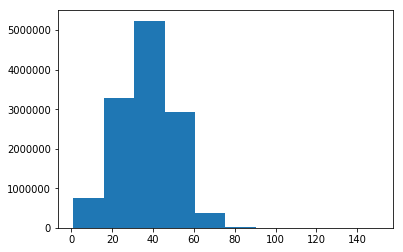

```python
plt.hist(tmc_selected_group['Unit_Sales_Price'])
```

#### as per the above plot we can see that the price distribution seems to be normal and majority of it lies in b/w 20 - 60

```python
tmc_1050 = tmc_selected_group[(tmc_selected_group['Total_Units']==1) & (tmc_selected_group['Dsubclass']==1050)]
```

```python
tmc_1050_price = tmc_1050[['Unit_Sales_Price','Total_Units']]
```

```python
plt.hist(tmc_1050_price['Unit_Sales_Price'])
```

[output not shown]

```python
bins = [0, 5, 10, 15, 20, 25, 30, 35, 40, 45, 50, 55, 60]
labels = ['0-5','5-10','10-15','15-20','20-25','25-30','30-35','35-40','40-45','45-50','50-55','55-60']
tmc_1050_price['binned'] = pd.cut(tmc_1050_price['Unit_Sales_Price'], bins=bins, labels=labels)
tmc_1050_price.head()
```

[output not shown]

#### In the similar way we will apply the Price Binning for all the transactions of the dataset

```python
print(tmc_selected_group['Unit_Sales_Price'].max())
print(tmc_selected_group['Unit_Sales_Price'].min())
```

```
150.0
1.0
```

#### since the overall Unit_Sales_Price ranges from 1.0 to 150.0, creating bins 50 bins where each bin_size =3

- i.e., price_bins = 0-3, 4-6, 7-9, 10-12 ........

```python
price_bins = np.arange(0,153,3)
price_bins = price_bins.tolist()
print(price_bins)
```

```
[0, 3, 6, 9, 12, 15, 18, 21, 24, 27, 30, 33, 36, 39, 42, 45, 48, 51, 54, 57, 60, 63, 66, 69, 72, 75, 78, 81, 84, 87, 90, 93, 96, 99, 102, 105, 108, 111, 114, 117, 120, 123, 126, 129, 132, 135, 138, 141, 144, 147, 150]
```

```python
price_labels = ['0-3','4-6','7-9','10-12','13-15','16-18','19-21','22-24','25-27','28-30','31-33','34-36','37-39','40-42',
                '43-45','46-48','49-51','52-54','55-57','58-60','61-63','64-66','67-69','70-72','73-75','76-78','79-81',
                '82-84','85-87','88-90','91-93','94-96','97-99','100-102','103-105','106-108','109-111','112-114','115-117',
                '118-120','121-123','124-126','127-129','130-132','133-135','136-138','139-141','142-144','145-147','148-150']
```

```python
tmc_selected_group['Unit_Sales_Price_Range'] = pd.cut(tmc_selected_group['Unit_Sales_Price'],
                                                      bins=price_bins, labels=price_labels)
```

```python
tmc_selected_group.head()
```

[output not shown]

#### Since we got the Unit_Sales_Price_Range for the Unit_Sales_Price of each tarnsaction, now we can drop Unit_Sales_Price

```python
tmc_selected_group = tmc_selected_group.drop('Unit_Sales_Price',axis=1)
```

```python
tmc_selected_group.head()
```

|  | Day_Dt | Dbsku | Full_Price_Ind | Total_Units | State | Store_Type | Store_Size | Dsubclass | date | doy | Year | season | Unit_Sales_Price_Range |
| --- | --- | --- | --- | --- | --- | --- | --- | --- | --- | --- | --- | --- | --- |
| 0 | 2015-09-26 | 466896 | 0 | 1 | SC | Lifestyle Center | 3050 | 1031 | 2015-09-26 | 269 | 2015 | fall | 16-18 |
| 1 | 2015-08-02 | 412445 | 0 | 1 | SC | Lifestyle Center | 3050 | 1021 | 2015-08-02 | 214 | 2015 | summer | 28-30 |
| 2 | 2015-10-21 | 491738 | 1 | 1 | SC | Lifestyle Center | 3050 | 1050 | 2015-10-21 | 294 | 2015 | fall | 43-45 |
| 3 | 2015-08-02 | 414979 | 0 | 1 | SC | Lifestyle Center | 3050 | 1032 | 2015-08-02 | 214 | 2015 | summer | 22-24 |
| 4 | 2015-07-26 | 458372 | 1 | 1 | SC | Lifestyle Center | 3050 | 1032 | 2015-07-26 | 207 | 2015 | summer | 46-48 |

```python
tmc_selected_group.dtypes
```

```
Day_Dt                    datetime64[ns]
Dbsku                              int32
Full_Price_Ind                      int8
Total_Units                        int16
State                           category
Store_Type                      category
Store_Size                         int16
Dsubclass                          int16
date                      datetime64[ns]
doy                                int64
Year                               int64
season                            object
Unit_Sales_Price_Range          category
dtype: object
```

#### In order not to have duplicates of similar type of transactions, grouping the data based on all necessary columns by summing up the Total_Units Sold

```python
tmc_group = tmc_selected_group.groupby(['Dbsku','Dsubclass','Store_Type','Store_Size','Unit_Sales_Price_Range','State','season','Full_Price_Ind'])['Total_Units'].sum().reset_index()
```

```python
tmc_group.shape
```

```
(8089829, 9)
```

#### If the above Group is formed by including Store_Size, the total no. of transactions = 8089829

#### If the above Group is formed by excluding Store_Size, the total no. of transactions are reduced to 4156384 as below

```python
tmc_selected_group = tmc_selected_group.drop(['Store_Size'],axis=1)
```

```python
tmc_group = tmc_selected_group.groupby(['Dbsku','Dsubclass','Store_Type','Unit_Sales_Price_Range','State','season','Full_Price_Ind'])['Total_Units'].sum().reset_index()
```

```python
tmc_group.shape
```

```
(4156384, 8)
```

This shows that "Store_size" adds a lot of variation to the data and by removing it groups the Data into a feasible set

#### Sample explanation of why Grouping has to be made

- Before grouping we will have many Duplicate transactions, for eg: as below

```python
tmc_finaldata[(tmc_finaldata.Dbsku==2999987) & (tmc_finaldata.Dsubclass==1252)
& (tmc_finaldata.Store_Type=='Tourist Outlet Strip') & (tmc_finaldata.State=='AZ') & (tmc_finaldata.Unit_Sales_Price==19.75)]
```

|  | Day_Dt | Dbsku | Full_Price_Ind | Total_Units | Unit_Sales_Price | State | Store_Type | Store_Size | Dsubclass | date | doy | Year | season | Unit_Sales_Price_Range |
| --- | --- | --- | --- | --- | --- | --- | --- | --- | --- | --- | --- | --- | --- | --- |
| 83742 | 2015-07-30 | 2999987 | 0 | 1 | 19.75 | AZ | Tourist Outlet Strip | 2866 | 1252 | 2015-07-30 | 211 | 2015 | summer | 19-21 |
| 128413 | 2015-09-22 | 2999987 | 0 | 1 | 19.75 | AZ | Tourist Outlet Strip | 2866 | 1252 | 2015-09-22 | 265 | 2015 | fall | 19-21 |
| 287119 | 2015-09-22 | 2999987 | 0 | 1 | 19.75 | AZ | Tourist Outlet Strip | 2920 | 1252 | 2015-09-22 | 265 | 2015 | fall | 19-21 |
| 491040 | 2015-09-14 | 2999987 | 0 | 1 | 19.75 | AZ | Tourist Outlet Strip | 2920 | 1252 | 2015-09-14 | 257 | 2015 | summer | 19-21 |
| 531377 | 2015-09-27 | 2999987 | 0 | 1 | 19.75 | AZ | Tourist Outlet Strip | 2920 | 1252 | 2015-09-27 | 270 | 2015 | fall | 19-21 |
| 613796 | 2015-09-17 | 2999987 | 0 | 1 | 19.75 | AZ | Tourist Outlet Strip | 2920 | 1252 | 2015-09-17 | 260 | 2015 | summer | 19-21 |
| 766893 | 2015-11-01 | 2999987 | 0 | 1 | 19.75 | AZ | Tourist Outlet Strip | 2920 | 1252 | 2015-11-01 | 305 | 2015 | fall | 19-21 |
| 804323 | 2015-08-27 | 2999987 | 0 | 1 | 19.75 | AZ | Tourist Outlet Strip | 2920 | 1252 | 2015-08-27 | 239 | 2015 | summer | 19-21 |
| 995749 | 2015-10-02 | 2999987 | 0 | 1 | 19.75 | AZ | Tourist Outlet Strip | 2920 | 1252 | 2015-10-02 | 275 | 2015 | fall | 19-21 |

- After grouping, the Duplicate transactions are combined on Total_Units Level

```python
tmc_group[(tmc_group.Dbsku==2999987) & (tmc_group.Dsubclass==1252)
& (tmc_group.Store_Type=='Tourist Outlet Strip') & (tmc_group.State=='AZ') & (tmc_group.Unit_Sales_Price_Range=='19-21')]
```

|  | Dbsku | Dsubclass | Store_Type | Unit_Sales_Price_Range | State | season | Full_Price_Ind | Total_Units |
| --- | --- | --- | --- | --- | --- | --- | --- | --- |
| 4156378 | 2999987 | 1252 | Tourist Outlet Strip | 19-21 | AZ | fall | 0 | 5 |
| 4156379 | 2999987 | 1252 | Tourist Outlet Strip | 19-21 | AZ | summer | 0 | 4 |

#### Creating Dummies for Dsubclass, Store_Type, season

```python
tmc_maindata = pd.get_dummies(tmc_group, columns= ['Dsubclass', 'Store_Type', 'season'])
```

#### Performing Label encoding for States, Unit_Sales_Price_Range instead of Dummies creation

```python
tmc_maindata['State'] = tmc_maindata['State'].cat.codes
tmc_maindata['Unit_Sales_Price_Range'] = tmc_maindata['Unit_Sales_Price_Range'].cat.codes
```

```python
print(tmc_maindata['State'].nunique())
print(tmc_maindata['Unit_Sales_Price_Range'].nunique())
```

[output not shown]

```python
tmc_maindata.head()
```

[output not shown]